# City Hotel Analysis

Andro Manukov

May 15, 2020

## Section 1: Introduction

Goal: Can we predict adr based on various factors?

## Section 2: Exploratory Data Analysis

```r
head(city_hotels)
```

```
## # A tibble: 6 x 18
##   hotel is_canceled lead_time arrival_date_ye~ arrival_date_mo~
##   <chr>       <dbl>     <dbl>            <dbl> <chr>
## 1 City~           0         0             2015 August
## 2 City~           0         1             2015 August
## 3 City~           0         5             2015 August
## 4 City~           0        39             2015 August
## 5 City~           0         3             2015 September
## 6 City~           0        82             2015 September
## # ... with 13 more variables: arrival_date_week_number <dbl>,
## #   arrival_date_day_of_month <dbl>, stays_in_weekend_nights <dbl>,
## #   stays_in_week_nights <dbl>, adults <dbl>, children <dbl>,
## #   babies <dbl>, meal <chr>, market_segment <chr>,
## #   reserved_room_type <chr>, customer_type <chr>, adr <dbl>,
## #   total_of_special_requests <dbl>
```

Categorical Variables: hotel, is_canceled, arrival_date_year, arrival_date_month, arrival_date_week_number, arrival_date_day_of_month, meal, market_segment, reserved_room_type, customer_type

Numerical: total_of_special_requests, adr, babies, children, adults, stays_in_week_nights, stays_in_weekend_nights, lead_time

Should we keep all time related variables in our analysis?

The only time related variable I am going to keep is arrival date month. I will use arrival date month to create a variable that classifies each month into a season. I think this will make the data analysis more concise and easier to work with, while also providing the same efficiency.

```r
city_hotels$arrival_season = "" #init variable
i = 1 #index for rows
for(val in city_hotels$arrival_date_month) #increment through each row
{
  if(val == "January" | val == "February" | val == "December") { #conditional
  city_hotels$arrival_season[i] = "Winter" #change to season
} else if(val == "March" | val == "May" | val == "April") {
  city_hotels$arrival_season[i] = "Spring"
} else if(val == "June" | val == "July" | val == "August") {
  city_hotels$arrival_season[i] = "Summer"
} else {
  city_hotels$arrival_season[i] = "Fall"
}

i = i + 1 #incremenet index
}
```

```r
city_hotels$total_stays <- city_hotels$stays_in_weekend_nights + city_hotels$stays_in_week_nights #creating total stays variable

city_hotels <- select(city_hotels, arrival_season, adults, children, meal, market_segment, customer_type, total_of_special_requests, total_stays, adr) #subsetting data
```

Didn’t keep babies because there are only two observations with one baby

```r
head(city_hotels)
```

```
## # A tibble: 6 x 9
##   arrival_season adults children meal  market_segment customer_type
##   <chr>           <dbl>    <dbl> <chr> <chr>          <chr>
## 1 Summer              2        0 SC    Online TA      Transient
## 2 Summer              2        0 SC    Online TA      Contract
## 3 Summer              2        0 BB    Direct         Transient
## 4 Summer              1        0 HB    Offline TA/TO  Transient-Pa~
## 5 Fall                2        0 BB    Online TA      Contract
## 6 Fall                2        0 BB    Online TA      Transient
## # ... with 3 more variables: total_of_special_requests <dbl>,
## #   total_stays <dbl>, adr <dbl>
```

Remove resereved room type because it varies between hotels so it’s not consistent.

Should we keep it in our analysis? Does ADR change depending on which season it is?:

```r
season_group <- summarise_at(group_by(city_hotels, arrival_season), vars(adr), funs(mean(.,na.rm=FALSE)))
```

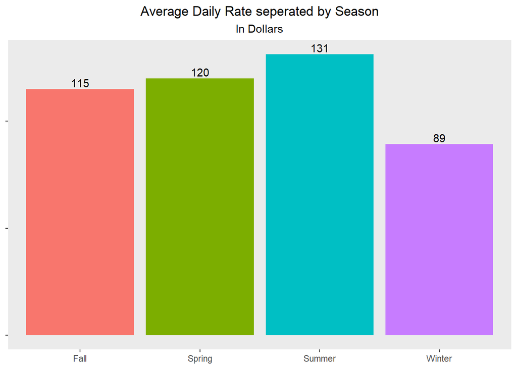

```r
ggplot(data = season_group, aes(x = arrival_season, y = adr, fill = arrival_season)) +
  geom_bar(position = 'dodge', stat='identity') +
  geom_text(aes(label= trunc(adr)), position=position_dodge(width=0.9), vjust=-0.25) +
  xlab("Season") + ylab("Average Daily Rate") + ggtitle("Average Daily Rate seperated by Season") + labs(subtitle = "In Dollars") +
  theme(legend.position = "none", panel.grid = element_blank(),
        axis.title = element_blank(),
        axis.text.y = element_blank(),
        plot.title = element_text(hjust = 0.5),
        plot.subtitle = element_text(hjust = 0.5))
```

Obviously a difference btween ADR based on season. Therefore I will keep this as the only time variable.

```r
head(city_hotels)
```

```
## # A tibble: 6 x 9
##   arrival_season adults children meal  market_segment customer_type
##   <chr>           <dbl>    <dbl> <chr> <chr>          <chr>
## 1 Summer              2        0 SC    Online TA      Transient
## 2 Summer              2        0 SC    Online TA      Contract
## 3 Summer              2        0 BB    Direct         Transient
## 4 Summer              1        0 HB    Offline TA/TO  Transient-Pa~
## 5 Fall                2        0 BB    Online TA      Contract
## 6 Fall                2        0 BB    Online TA      Transient
## # ... with 3 more variables: total_of_special_requests <dbl>,
## #   total_stays <dbl>, adr <dbl>
```

## Section 3: Method

#### Section 3.1

```r
simple_lm <- lm(adr ~ ., data = city_hotels)
summary(simple_lm)
```

```
##
## Call:
## lm(formula = adr ~ ., data = city_hotels)
##
## Residuals:
##      Min       1Q   Median       3Q      Max
## -127.593  -22.932   -1.841   17.929  160.795
##
## Coefficients:
##                              Estimate Std. Error t value Pr(>|t|)
## (Intercept)                   95.3883    35.4265   2.693  0.00716 **
## arrival_seasonSpring          -2.0797     2.5112  -0.828  0.40770
## arrival_seasonSummer           2.4079     2.4692   0.975  0.32961
## arrival_seasonWinter         -29.2277     3.2043  -9.121  < 2e-16 ***
## adults                        19.9780     1.6736  11.937  < 2e-16 ***
## children                      30.5458     1.8362  16.635  < 2e-16 ***
## mealHB                        38.9201     6.4396   6.044 1.87e-09 ***
## mealSC                       -21.0557     2.1037 -10.009  < 2e-16 ***
## market_segmentComplementary  -28.9292    49.6503  -0.583  0.56020
## market_segmentCorporate      -17.4469    35.0099  -0.498  0.61831
## market_segmentDirect           5.9870    34.3923   0.174  0.86182
## market_segmentGroups         -28.3137    34.6405  -0.817  0.41385
## market_segmentOffline TA/TO  -26.4610    34.5218  -0.766  0.44349
## market_segmentOnline TA       -4.5432    34.3681  -0.132  0.89485
## customer_typeGroup            -5.6232    13.7980  -0.408  0.68367
## customer_typeTransient        -1.1340     8.5454  -0.133  0.89445
## customer_typeTransient-Party -10.1873     9.3383  -1.091  0.27547
## total_of_special_requests      2.8264     1.0391   2.720  0.00660 **
## total_stays                   -0.6046     0.3898  -1.551  0.12110
## ---
## Signif. codes:  0 '***' 0.001 '**' 0.01 '*' 0.05 '.' 0.1 ' ' 1
##
## Residual standard error: 34.23 on 1599 degrees of freedom
## Multiple R-squared:  0.4327, Adjusted R-squared:  0.4263
## F-statistic: 67.76 on 18 and 1599 DF,  p-value: < 2.2e-16
```

#### Section 3.2

```r
lm_model = step(simple_lm, direction = "backward")
```

```
## Start:  AIC=11451.71
## adr ~ arrival_season + adults + children + meal + market_segment +
##     customer_type + total_of_special_requests + total_stays
##
##                             Df Sum of Sq     RSS   AIC
## - customer_type              3      6617 1879816 11451
## <none>                                   1873199 11452
## - total_stays                1      2818 1876017 11452
## - total_of_special_requests  1      8668 1881866 11457
## - market_segment             6     74284 1947483 11503
## - arrival_season             3    143516 2016715 11565
## - meal                       2    165917 2039116 11585
## - adults                     1    166926 2040125 11588
## - children                   1    324174 2197372 11708
##
## Step:  AIC=11451.42
## adr ~ arrival_season + adults + children + meal + market_segment +
##     total_of_special_requests + total_stays
##
##                             Df Sum of Sq     RSS   AIC
## <none>                                   1879816 11451
## - total_stays                1      2654 1882470 11452
## - total_of_special_requests  1      8193 1888009 11456
## - arrival_season             3    142518 2022334 11564
## - meal                       2    160611 2040427 11580
## - adults                     1    171580 2051396 11591
## - market_segment             6    208317 2088133 11610
## - children                   1    328828 2208644 11710
```

```r
summary(lm_model)
```

```
##
## Call:
## lm(formula = adr ~ arrival_season + adults + children + meal +
##     market_segment + total_of_special_requests + total_stays,
##     data = city_hotels)
##
## Residuals:
##      Min       1Q   Median       3Q      Max
## -127.544  -22.717   -1.944   17.728  161.403
##
## Coefficients:
##                             Estimate Std. Error t value Pr(>|t|)
## (Intercept)                  93.9409    34.4179   2.729  0.00641 **
## arrival_seasonSpring         -2.4395     2.4743  -0.986  0.32433
## arrival_seasonSummer          1.9846     2.4313   0.816  0.41446
## arrival_seasonWinter        -29.4082     3.1828  -9.240  < 2e-16 ***
## adults                       20.1645     1.6676  12.092  < 2e-16 ***
## children                     30.7310     1.8358  16.740  < 2e-16 ***
## mealHB                       37.5507     6.4181   5.851 5.92e-09 ***
## mealSC                      -20.6381     2.0967  -9.843  < 2e-16 ***
## market_segmentComplementary -33.3459    48.4693  -0.688  0.49156
## market_segmentCorporate     -20.6398    35.0115  -0.590  0.55560
## market_segmentDirect          5.8602    34.4183   0.170  0.86482
## market_segmentGroups        -37.0514    34.4681  -1.075  0.28256
## market_segmentOffline TA/TO -31.3324    34.4873  -0.909  0.36374
## market_segmentOnline TA      -4.7963    34.3938  -0.139  0.88911
## total_of_special_requests     2.7362     1.0355   2.642  0.00831 **
## total_stays                  -0.5865     0.3900  -1.504  0.13281
## ---
## Signif. codes:  0 '***' 0.001 '**' 0.01 '*' 0.05 '.' 0.1 ' ' 1
##
## Residual standard error: 34.26 on 1602 degrees of freedom
## Multiple R-squared:  0.4307, Adjusted R-squared:  0.4254
## F-statistic:  80.8 on 15 and 1602 DF,  p-value: < 2.2e-16
```